# Stochastic SuSiE for general likelihoods

Karl Tayeb

2022-02-07

## Why?

We’d like a generic way to perform inference for sparse regression with a SuSiE, *for an arbitrary likelihood*. In particular, we’d like to make it possible for a user to run a valid SuSiE regression provided an implementation of a univariate regression (satisfying some small number of requirements).

Here’s the idea: it is always easy to perform inference in single effect regression (SER), because it amounts to (1) performing $p$ univariate Bayesian regressions, and (2) averaging over these $p$ models. Even for non-conjugate likelihoods, we can always perform 1d integration. In contrast, the sum of single effects regression (SuSiE) is challenging to perform inference in. The variational approximation for SuSiE $q(b, \gamma) = \prod_l q(b_l, \gamma_l)$ is sufficient to dramatically simplify inference in the linear case. However, for general likelihoods we are not so lucky, and the evaluation of the lower bound involves explicity summing over $L^p$ configurations of the selected variables.

Here we propose a stochastic optimization of the SuSiE ELBO, which let’s us improve the ELBO by fitting a sequence of SERs. This let’s us keep the basic “unit” of computation evaluating a univariate logistic regression, but extends SuSiE to arbitrary likelihoods. Our requirement will be that we can fit a fixed-form variational approximation to the univariate logistic regression, where $q(b)$ is constrained to be normal.

## Stochastic optimization

The SuSiE ELBO:

$$\mathcal L(q) = \mathbb E_q\left[\log p (y | X, b, \gamma) \right] -
KL\left[q(b, \gamma) || p(b, \gamma) \right]$$

For the family that factorizes as $q(b, \gamma) = \prod_l q(b_l, \gamma_l)$, written as a function of $q_l= q(b_l, \gamma_l)$

$$\mathcal L(q_l) = \mathbb E_{q_{-l}}\left[\mathbb E_{q_{l}}\left[
\log p (y | X, b_l, \gamma_l, b_{-l}, \gamma_{-l}) \right]\right]
- KL\left[q(b_l, \gamma_l) || p(b_l, \gamma_l)
\right] + C$$
Where $C$ is a constant that absorbs terms not dependent on $q_l$. and $b_{-l}$, $\gamma_{-l}$ denote the $L-1$ other SER parameters.

We can take a Monte-Carlo estimate of the outer expectation by sampling from $q_{-l}$. Let $b^{(m)}_{-l}$ and $\gamma^{(m)}_{-l}$ denote samples from $q_{-l}$, we can get an unbiased estimate of the ELBO by

$$\hat{\mathcal L}(q_l) = \frac{1}{M} \sum \mathbb E_{q_{l}}\left[
\log p (y | X, b_l, \gamma_l, b_{-l}^{(m)}, \gamma_{-l}^{(m)})
- KL\left[q(b_l, \gamma_l) || p(b_l, \gamma_l)
\right]\right] + C \approx \mathcal L(q_l)$$

Notice the term in the sum is the ELBO for a SER where $b_{-l}$ and $\gamma_{-l}$ are known. If we fit a fixed-form variational approximation for this SER $q^{(m)}(b_l, \gamma_l)$, where $q^{(m)}(b_l | \gamma_l)$ is constrained to be Gaussian (or more generally, $q^{(m)}(b | \gamma)$ and $p(b)$ are the same exponential family), then (I claim) we can get a Monte-carlo estimate of the best fixed-form approximation for $q(b_l, \gamma_l)$ by averaging the natural parameters of $q^{(m)}$.

This is true for the linear model (where the likelihood is conditionally conjugate, and the best unconstrained approximation for $q(b | \gamma)$ is Gaussian). It may take a little extra work to justify that it’s the right thing to do for other likelihoods.

## Code

### Linear SER

```r
linear_ser <- function(X, y, o, residual_variance=var(y), prior_variance=1, estimate_intercept=T, estimate_residual_variance=F,...){
  # form the residual, center
  if(is.list(o)) {
    # if o = list(mu, var), just take o$mu for offset
    o <- o$mu
  }
  r <- y - o
  r <- r - mean(r)

  # do linear regression, assumes columns of X are mean 0
  yTx <- (r %*% X)[1,]
  xTx <- purrr::map_dbl(1:ncol(X), ~sum(X[, .x]^2))
  betahat = yTx / xTx

  # form final posterior
  shat2 <- residual_variance / xTx

  lbf <- 0.5 * log(shat2 / (prior_variance + shat2)) + (0.5 * betahat^2/shat2 * prior_variance/(prior_variance + shat2))
  alpha <- exp(lbf - matrixStats::logSumExp(lbf))
  post_var <- 1 / (1/ prior_variance + 1/shat2)
  post_mean <- post_var/shat2 * betahat

  res <- list(
    alpha = alpha,
    mu = post_mean,
    var = post_var,
    lbf = lbf,
    lbf_model = matrixStats::logSumExp(lbf) - log(length(lbf)),
    prior_variance=prior_variance
  )
  return(res)
}
```

### Stochastic optimization for SER/SuSiE

```r
#' convert mean/variance to natural parameters
normal_mean2natural <- function(mu, var){
  eta1 <- mu/var
  eta2 <- -0.5 / var
  return(list(eta1=eta1, eta2=eta2))
}

#' convert natural parameters to mean/variance
normal_natural2mean <- function(eta1, eta2){
  mu <- -0.5 * eta1 / eta2
  var <- mu / eta1
  return(list(mu=mu, var=var))
}

#' a convex combination of the natural parameters of two normal distributions
normal_update <- function(mu, var, mu_new, var_new, lambda){
  # convert to natural parameter space
  eta <- normal_mean2natural(mu, var)
  eta_new <- normal_mean2natural(mu_new, var_new)

  # combine
  eta1 <- eta$eta1 * lambda + eta_new$eta1 * (1 - lambda)
  eta2 <- eta$eta2 * lambda + eta_new$eta2 * (1 - lambda)

  # convert back to mean/variance
  return(normal_natural2mean(eta1, eta2))
}


#' convert categorical probabilities to natural parameters
categorical_mean2natural <- function(pi){
  K <- length(pi)
  logpi <- log(pi)
  logpi[is.infinite(logpi)] <- -1e10
  return(head(logpi - logpi[K], K-1))
}

#' convert categorical natural parameters to probabilities
categorical_natural2mean <- function(eta){
  K <- length(eta) + 1
  eta <- c(eta, 0)
  pi <- exp(eta - matrixStats::logSumExp(eta))
  return(pi)
}

#' convex combination of natural paramaters of two probability vectors
categorical_update <- function(pi, pi_new, lambda){
  # convert to natural parameter space
  eta <- categorical_mean2natural(pi)
  eta_new <- categorical_mean2natural(pi_new)

  # combine
  eta <- eta * lambda + eta_new * (1 - lambda)

  # convert back to mean/variance
  return(categorical_natural2mean(eta))
}

#' Update q SER
#'
#' Average natural parameters of two SERs
#' Each q is an SER posterior, a list with `mu`, `var`, and `lambda`
#' @param q1 an SER posterior
#' @param q2 an SER posterior
#' @param lambda in [0, 1], how much to weight q1
update_q_ser <- function(q1, q2, lambda){
    q <- normal_update(q1$mu, q1$var, q2$mu, q2$var, lambda=lambda)
    q$alpha <- categorical_update(q1$alpha, q2$alpha, lambda=lambda)
    return(q)
}
```

```r
#' Sample gamma from the SuSiE posterior
susie_sample_gamma <- function(alpha){
  L <- nrow(alpha)
  p <- ncol(alpha)

  gamma <- vector('numeric', L)
  for(l in 1:L){
    gamma[l] <- sample(p, 1, prob=alpha[l,])
  }
  return(gamma)
}

#' Sample b | gamma from the SuSiE posterior
susie_sample_b <- function(gamma, mu, var){
  L <- length(gamma)
  b <- vector('numeric', L)
  for(l in 1:L){
    b[l] <- rnorm(1, mean=mu[l, gamma[l]], sd=sqrt(var[l, gamma[l]]))
  }
  return(b)
}

#' Sample offset
#'
#' Computes a Monte-Carlo sample of X E[b]
#' where `b` is sampled from `fit`
#' @param fit a susie fit (minimally, a list with `alpha`, `mu`, `var`)
#' @param X an n x p matrix
#' @l a single effect to exclude/zero-out (defalt 0, don't remove any single effect)
#' @sample_b whether to sample `b_l` if false
#' @return an offset, which is a list containing `mu` and `var`.
#'  If `sample_b=T` `mu` is the sample predictions, and `var` is a vector of 0s
#'  Otherwise `mu` is the E_q[Xb | gamma] and `var` is Var_q[Xb | gamma]
sample_offset <- function(fit, X, l=0, sample_b=T){
  gamma <- with(fit, susie_sample_gamma(alpha))
  L <- length(gamma)
  if(sample_b){
    b <- with(fit, susie_sample_b(gamma, mu, var))
    b[l] <- 0  # 0 out the effect (note if l=0 this does nothing)
    o <- list(mu = (X[, gamma] %*% b)[, 1], var = rep(0, nrow(X)))
  } else {
    mu <- purrr::map_dbl(1:L, ~fit$mu[.x, gamma[.x]])
    var <- purrr::map_dbl(1:L, ~fit$var[.x, gamma[.x]])
    mu[l] <- 0  # 0 out effect l
    var[l] <- 0

    mu <- (X[, gamma] %*% mu)[, 1]
    mu2 <- (X[, gamma]^2 %*% var)[,1] + mu^2
    o <- list(mu = mu, mu2=mu2)
  }
  return(o)
}

#' Initialize q SER
#'
#' A simple initialization for the SER posterior, initialize to prior
#' @param p number of features
#' @param prior_variance prior variance of the effect
initialize_q_ser <- function(p, prior_variance=1){
  post <- list(
    mu = rep(0, p),
    var = rep(prior_variance, p),
    alpha = rep(1/p, p)
  )
  return(post)
}
```

```r
kl_ser <- function(q1, q2){
  kl <- logisticsusie:::categorical_kl(q1$alpha, q2$alpha)
  kl <- kl + sum(q1$alpha * logisticsusie:::normal_kl(q1$mu, q1$var, q2$mu, q2$var))
  return(kl)
}

kl_ser_sym <- function(q1, q2){
  kl_ser(q1, q2) + kl_ser(q2, q1)
}
```

```r
#' Samples from fit, and fits an SER with the offset
#' then combines the results by averaging natural parameters
stochastic_ser <- function(X, y, fit, l, niter=100, q_init=NULL, history=F, ser_fun=NULL, sample_b=T){
  # 0: setup
  p <- ncol(fit$alpha)

  # if no ser specified, default to linear
  if(is.null(ser_fun)){
    ser_fun = linear_ser
  }

  if(is.null(q_init)){      # initialize posterior if not provided
    o <- sample_offset(fit, X, l=l, sample_b = sample_b)
    post <- ser_fun(X, y, o)
  } else{
    post <- q_init
  }

  # run stochastic updates for 100 iterations
  post_history <- list()
  for (iter in 1: niter){
    # 1. sample the L-1 effects (removing effect l)
    o <- sample_offset(fit, X, l=l, sample_b=sample_b)

    # 2. fit SER with sampled offset
    ser <- ser_fun(X, y, o)

    # 3. keep running average of natural parameters
    post <- update_q_ser(post, ser, 1 - 1/(iter + 1))

    if(history){
      post_history[[iter]] <- post
    }

  }

  if(history){
    return(post_history)
  } else{
    return(post)
  }
}
```

Use stochastic SER to make stochastic SuSiE

```r
update_fit <- function(fit, ser, l){
  fit$alpha[l,] <- ser$alpha
  fit$mu[l,] <- ser$mu
  fit$var[l,] <- ser$var
  return(fit)
}

stochastic_susie <- function(X, y, L, prior_variance=1., niter=100, ser_iter = 100, history=F, ser_fun=NULL, sample_b=T){
  # 0: setup
  n <- length(y)
  p <- ncol(X)

  # initialize
  fit <- list(
    alpha = matrix(rep(1/p, p*L), nrow = L),
    mu = matrix(rep(0, p*L), nrow = L),
    var = matrix(rep(prior_variance, p*L), nrow = L)
  )
  post_history <- list()

  # initialize_sers
  sers <- purrr::map(1:L, ~initialize_q_ser(p))

  for (iter in 1: niter){
    for (l in 1:L){
      # TODO: set q_init = sers[[l]]?
      # right now it doesnt make much difference, only weighed as 1 sample
      ser_l <- stochastic_ser(X, y, fit, l, niter=ser_iter, ser_fun=ser_fun, sample_b = sample_b)
      sers[[l]] <- ser_l
      fit <- update_fit(fit, ser_l, l)
    }
    if(history){
      post_history[[iter]] <- fit
    }
  }
  if(history){
    return(post_history)
  } else{
    return(fit)
  }
}

susie_plot2 <- function(fit, X, y = "PIP", ...) {
  fit$pip <- logisticsusie:::compute_pip(fit$alpha)
  fit$sets <- susieR::susie_get_cs(fit, X = X)
  class(fit) <- "susie"
  susieR::susie_plot(fit, y, ...)
}
```

## SER Examples

### Recovering a single SuSiE component: stochastic approdimation for Linear SER

We use a toy simulation with 3 effects, and fit linear SuSiE as a baseline. Our goal here is to estimate $q(b_3, \gamma_3)$ using our stochastic approach. We fix the residual variance $\sigma^2 = Var(y)$ where $Var(y)$ is the sample variance, and the prior variance $\sigma^2_0 = 1$. We see that as we average the natural parameters across many draws of $\gamma_{-l}$, or $\{\gamma_{-l}, b_{-l}\}$ we approach the exact SER solution. Unsurprisingly, when we only sample over configurations, the convergence is much faster.

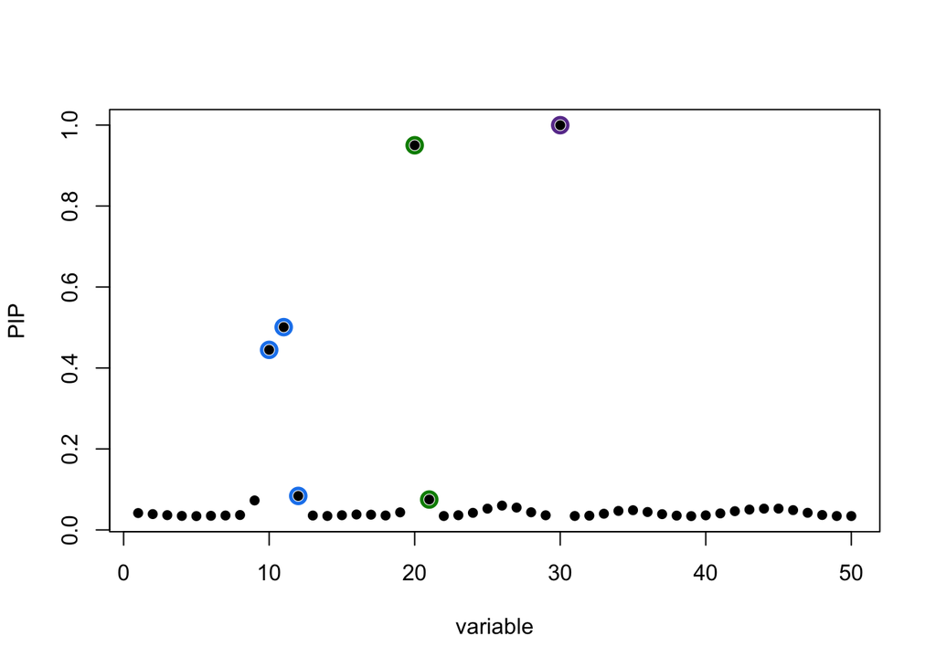

```r
# simulate data
set.seed(5)
sim <- logisticsusie::sim_susie(length_scale = 10)

# standardize data
data <- with(sim, {
  y <- y - mean(y)
  X <- scale(X)
  list(y=y, X=X)
})

# fit SuSiE
susie_fit <- with(data, susieR::susie(
  X, y, L = 5, scaled_prior_variance = 1, estimate_prior_variance = F, estimate_residual_variance = F))
susieR::susie_plot(susie_fit, 'PIP')
```

```r
susie_fit$var <- susie_fit$mu2 - susie_fit$mu^2
susie_l3 <- list(
  alpha=susie_fit$alpha[3,],
  mu=susie_fit$mu[3,],
  var=susie_fit$var[3,]
)
```

```r
# stochastic SER, sampling b
max_iter <- 1000
stochastic_l3_b <- with(data, stochastic_ser(
  X, y, susie_fit, 3, niter=max_iter, history = T, sample_b = T))
# compute symmetrized KL between stochastic SER and exact SER posterior
kls_b <- purrr::map_dbl(1:length(stochastic_l3_b), ~ kl_ser_sym(susie_l3, stochastic_l3_b[[.x]]))


# stochastic SER, integrate over b
stochastic_l3_Eb <- with(data, stochastic_ser(
  X, y, susie_fit, 3, niter=max_iter, history = T, sample_b = F))
kls_Eb <- purrr::map_dbl(1:length(stochastic_l3_Eb), ~ kl_ser_sym(susie_l3, stochastic_l3_Eb[[.x]]))
```

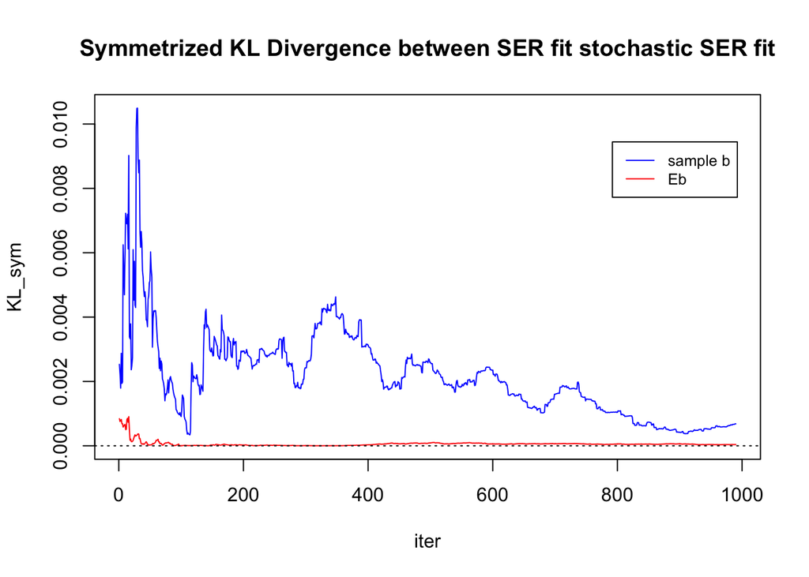

```r
s <- 10
kls_b_trunc <- tail(kls_b, -s)
kls_Eb_trunc <- tail(kls_Eb, -s)
yrange <- range(c(0, kls_b_trunc, kls_Eb_trunc))
plot(kls_b_trunc,
     col = 'blue',
     xlab='iter',
     ylab = 'KL_sym',
     type = 'line',
     ylim = yrange,
     main='Symmetrized KL Divergence between SER fit stochastic SER fit'
)
lines(kls_Eb_trunc, col='red')

abline(0, 0, col='black', lty='dotted')

# Add a legend
legend(
  x = length(kls_Eb_trunc) * 0.8,
  y = yrange[2] * 0.9,
  legend = c('sample b', 'Eb'),
  lty = c('solid', 'solid'),
  col = c('blue', 'red'),
  cex=0.8
)
```

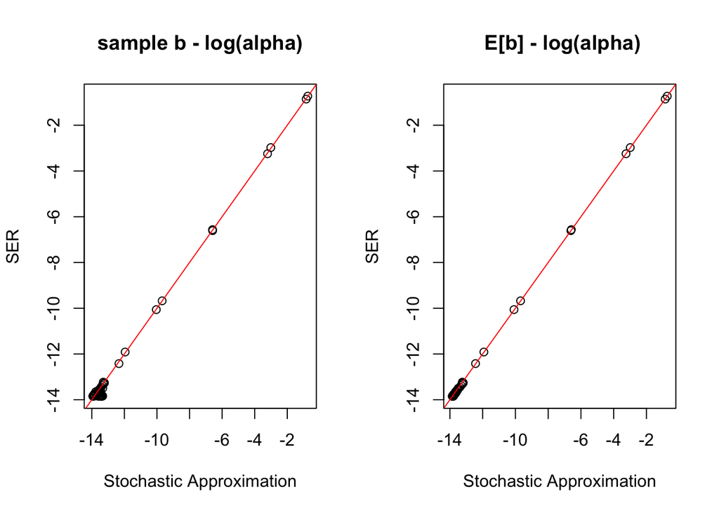

```r
par(mfrow = c(1, 2))
plot(log(stochastic_l3_b[[max_iter]]$alpha),
     log(susie_l3$alpha),
     xlab = 'Stochastic Approximation',
     ylab = 'SER',
     main = 'sample b - log(alpha)')
abline(0, 1, col='red')

plot(log(stochastic_l3_Eb[[max_iter]]$alpha),
     log(susie_l3$alpha),
     xlab = 'Stochastic Approximation',
     ylab = 'SER',
     main = ' E[b] - log(alpha)')
abline(0, 1, col='red')
```

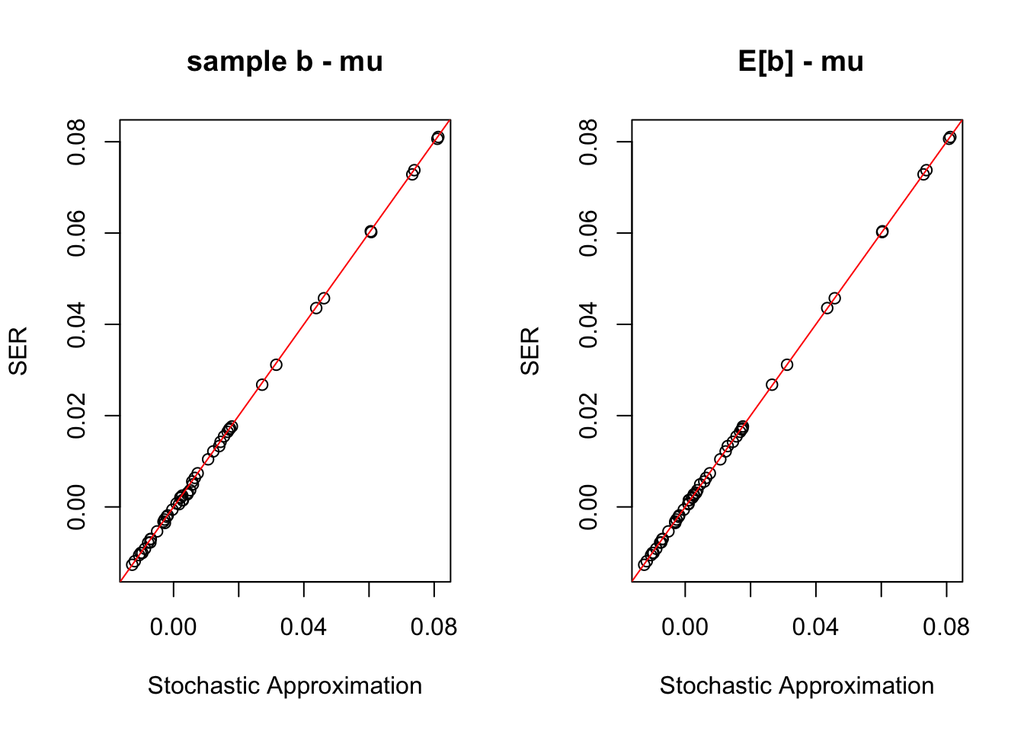

```r
par(mfrow = c(1, 2))
plot(stochastic_l3_b[[max_iter]]$mu,
     susie_l3$mu,
     xlab = 'Stochastic Approximation',
     ylab = 'SER',
     main = 'sample b - mu')
abline(0, 1, col='red')

plot(stochastic_l3_Eb[[max_iter]]$mu,
     susie_l3$mu,
     xlab = 'Stochastic Approximation',
     ylab = 'SER',
     main = ' E[b] - mu')
abline(0, 1, col='red')
```

Note: there seems to be some slight disagreement between our computation of the posterio variance and `susieR`’s. Since we are giving standardized `X` in this example, posterior variance is the same for all features. s

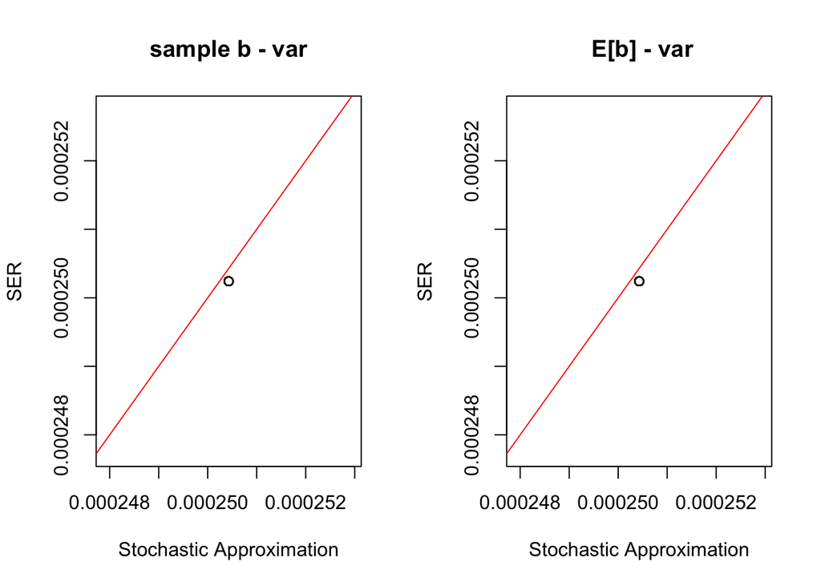

```r
par(mfrow = c(1, 2))
plot(stochastic_l3_b[[max_iter]]$var,
     susie_l3$var,
     xlab = 'Stochastic Approximation',
     ylab = 'SER',
     main = 'sample b - var')
abline(0, 1, col='red')

plot(stochastic_l3_Eb[[max_iter]]$var,
     susie_l3$var,
     xlab = 'Stochastic Approximation',
     ylab = 'SER',
     main = ' E[b] - var')
abline(0, 1, col='red')
```

### A harder example

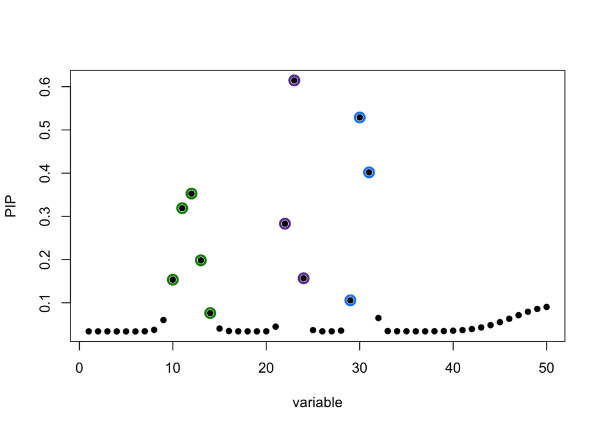

```r
# simulate data
set.seed(110)
sim <- logisticsusie::sim_susie(length_scale = 50)

# standardize data
data <- with(sim, {
  y <- y - mean(y)
  X <- scale(X)
  list(y=y, X=X)
})

# fit SuSiE
susie_fit <- with(data, susieR::susie(
  X, y, L = 5, scaled_prior_variance = 1, estimate_prior_variance = F, estimate_residual_variance = F))
susieR::susie_plot(susie_fit, 'PIP')
```

```r
susie_fit$var <- susie_fit$mu2 - susie_fit$mu^2
susie_l3 <- list(
  alpha=susie_fit$alpha[3,],
  mu=susie_fit$mu[3,],
  var=susie_fit$var[3,]
)
```

```r
# stochastic SER, sampling b
max_iter <- 1000
stochastic_l3_b <- with(data, stochastic_ser(
  X, y, susie_fit, 3, niter=max_iter, history = T, sample_b = T))
# compute symmetrized KL between stochastic SER and exact SER posterior
kls_b <- purrr::map_dbl(1:length(stochastic_l3_b), ~ kl_ser_sym(susie_l3, stochastic_l3_b[[.x]]))


# stochastic SER, integrate over b
stochastic_l3_Eb <- with(data, stochastic_ser(
  X, y, susie_fit, 3, niter=max_iter, history = T, sample_b = F))
kls_Eb <- purrr::map_dbl(1:length(stochastic_l3_Eb), ~ kl_ser_sym(susie_l3, stochastic_l3_Eb[[.x]]))
```

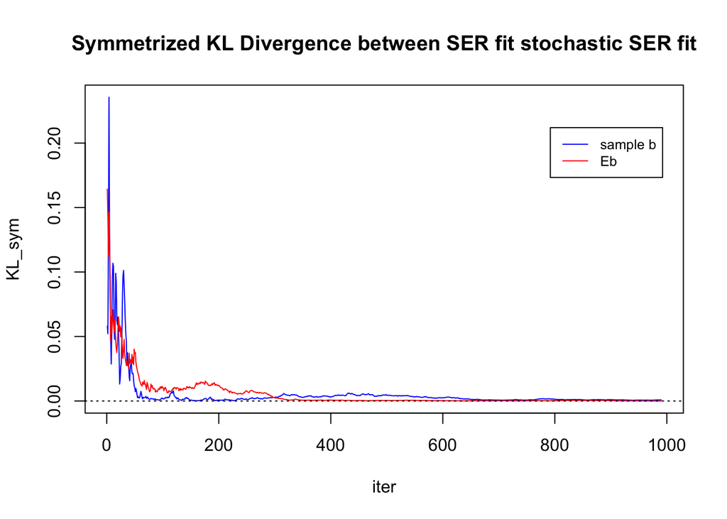

```r
s <- 10
kls_b_trunc <- tail(kls_b, -s)
kls_Eb_trunc <- tail(kls_Eb, -s)
yrange <- range(c(0, kls_b_trunc, kls_Eb_trunc))
plot(kls_b_trunc,
     col = 'blue',
     xlab='iter',
     ylab = 'KL_sym',
     type = 'line',
     ylim = yrange,
     main='Symmetrized KL Divergence between SER fit stochastic SER fit'
)
lines(kls_Eb_trunc, col='red')

abline(0, 0, col='black', lty='dotted')

# Add a legend
legend(
  x = length(kls_Eb_trunc) * 0.8,
  y = yrange[2] * 0.9,
  legend = c('sample b', 'Eb'),
  lty = c('solid', 'solid'),
  col = c('blue', 'red'),
  cex=0.8
)
```

We see that it takes longer for the stochastic SER to converge to the exact posterior computation.

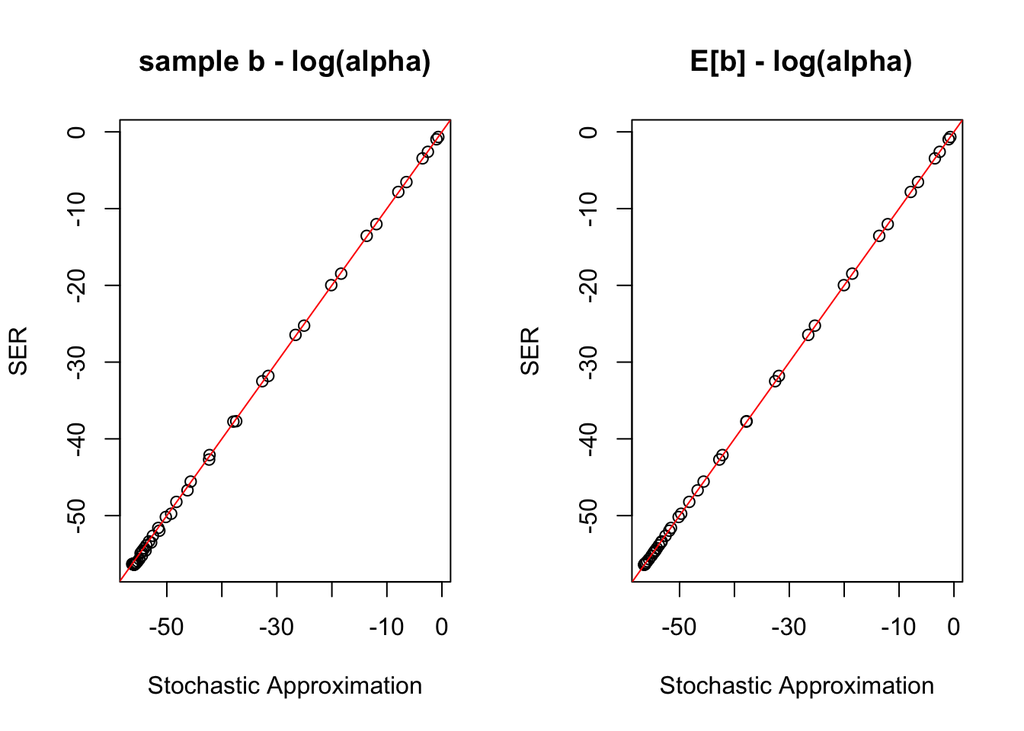

```r
par(mfrow = c(1, 2))
plot(log(stochastic_l3_b[[max_iter]]$alpha),
     log(susie_l3$alpha),
     xlab = 'Stochastic Approximation',
     ylab = 'SER',
     main = 'sample b - log(alpha)')
abline(0, 1, col='red')

plot(log(stochastic_l3_Eb[[max_iter]]$alpha),
     log(susie_l3$alpha),
     xlab = 'Stochastic Approximation',
     ylab = 'SER',
     main = ' E[b] - log(alpha)')
abline(0, 1, col='red')
```

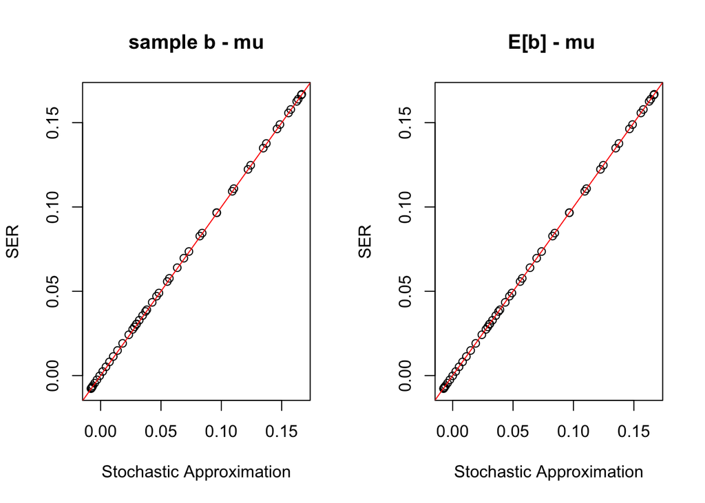

```r
par(mfrow = c(1, 2))
plot(stochastic_l3_b[[max_iter]]$mu,
     susie_l3$mu,
     xlab = 'Stochastic Approximation',
     ylab = 'SER',
     main = 'sample b - mu')
abline(0, 1, col='red')

plot(stochastic_l3_Eb[[max_iter]]$mu,
     susie_l3$mu,
     xlab = 'Stochastic Approximation',
     ylab = 'SER',
     main = ' E[b] - mu')
abline(0, 1, col='red')
```

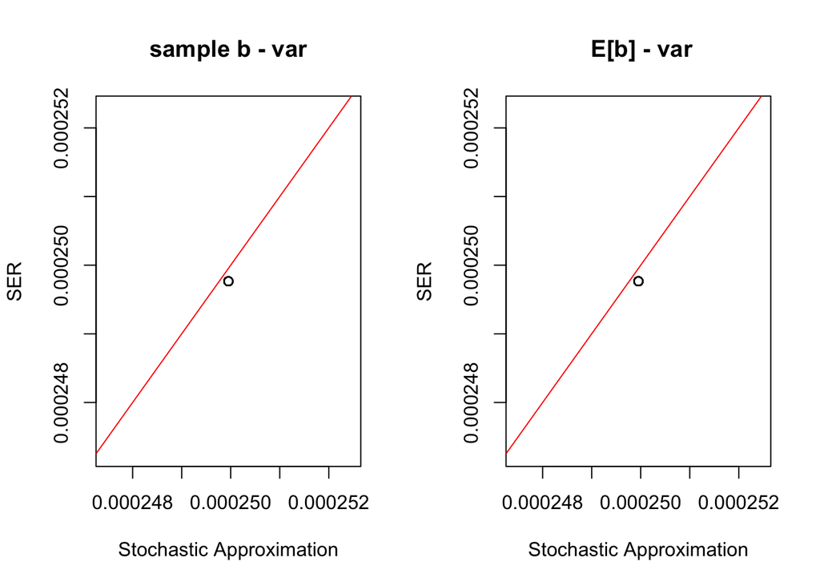

```r
par(mfrow = c(1, 2))
plot(stochastic_l3_b[[max_iter]]$var,
     susie_l3$var,
     xlab = 'Stochastic Approximation',
     ylab = 'SER',
     main = 'sample b - var')
abline(0, 1, col='red')

plot(stochastic_l3_Eb[[max_iter]]$var,
     susie_l3$var,
     xlab = 'Stochastic Approximation',
     ylab = 'SER',
     main = ' E[b] - var')
abline(0, 1, col='red')
```

## SuSiE Examples

### Linear SuSiE Test

```r
library(tictoc)

# simulate data
set.seed(10)
sim <- logisticsusie::sim_susie(length_scale = 20)

# standardize data
data <- with(sim, {
  y <- y - mean(y)
  X <- scale(X)
  list(y=y, X=X)
})

tic('ibss')
ibss_fit <- with(data, logisticsusie::ibss_from_ser(
  X, y, L=5, prior_variance = 1, ser_function = linear_ser))
```

```
## ibss: 0.062 sec elapsed
```

```r
toc()
```

```
## 0.066 sec elapsed
```

```r
tic('stochastic ibss')
stochastic_fit_b <- with(data, stochastic_susie(
  X, y, L=5, niter = 20, ser_iter = 100, history = T, sample_b = T))
toc()
```

```
## stochastic ibss: 9.633 sec elapsed
```

```r
tic('stochastic ibss')
stochastic_fit_Eb <- with(data, stochastic_susie(
  X, y, L=5, niter = 20, ser_iter = 100, history = T, sample_b = F))
toc()
```

```
## stochastic ibss: 10.113 sec elapsed
```

```r
tic('susie')
susie_fit <- with(data, susieR::susie(
  X, y, L = 5, scaled_prior_variance = 1, estimate_prior_variance = F))
toc()
```

```
## susie: 0.03 sec elapsed
```

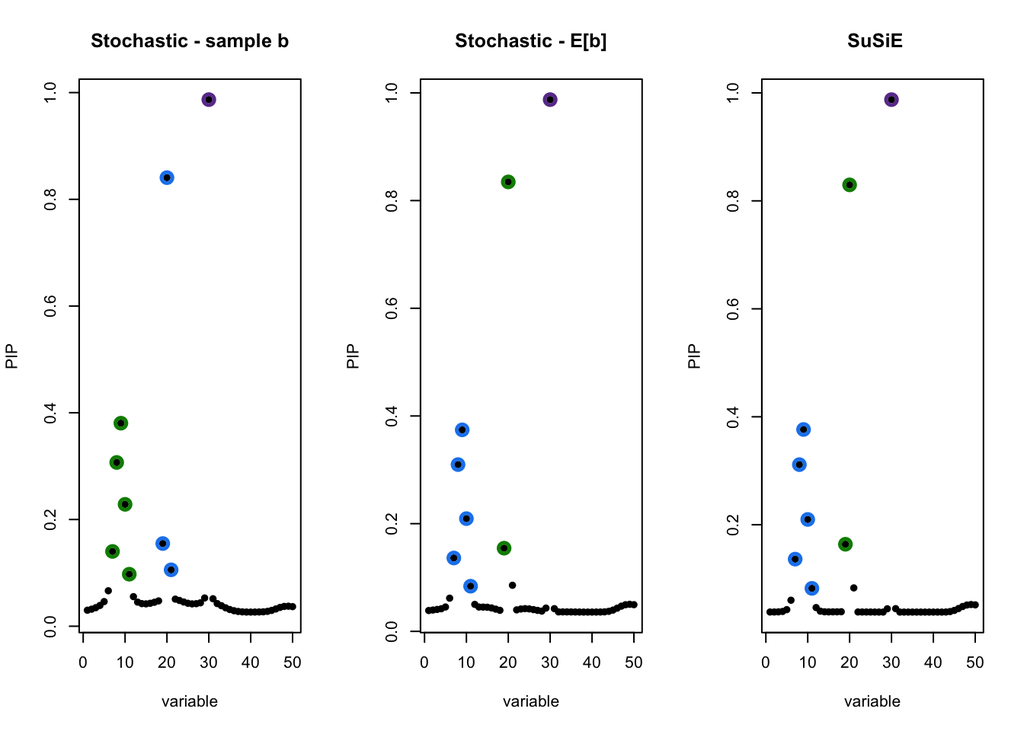

```r
par(mfrow = c(1, 3))
susie_plot2(stochastic_fit_b[[20]], data$X, main = 'Stochastic - sample b')
susie_plot2(stochastic_fit_Eb[[20]], data$X, main = 'Stochastic - E[b]')
susie_plot2(ibss_fit, data$X, main =' SuSiE')
```

### Logistic SuSiE Test

On a small example, we see comparable performance between our stochastic approximation moment-mathcing

```r
library(tictoc)

# simulate data
set.seed(12)
sim <- logisticsusie::sim_susie(length_scale = 20)

# standardize X
data <- with(sim, {
  y <- y
  X <- scale(X)
  list(y=y, X=X)
})

tic('ibss')
ibss_uvb_fit <- with(data, logisticsusie::ibss_from_ser(
  X, y, L=5, prior_variance = 1, ser_function = logisticsusie::fit_uvb_ser))
```

```
## ibss: 2.672 sec elapsed
```

```r
toc()
```

```
## 2.673 sec elapsed
```

```r
tic('stochastic uvb')
stochastic_uvb_re_fit <- with(data, stochastic_susie(
  X, y, L=5, niter = 10, ser_iter = 10, history = T, ser_fun = logisticsusie::fit_uvb_ser_re, sample_b = F))
toc()
```

```
## stochastic uvb: 35.25 sec elapsed
```

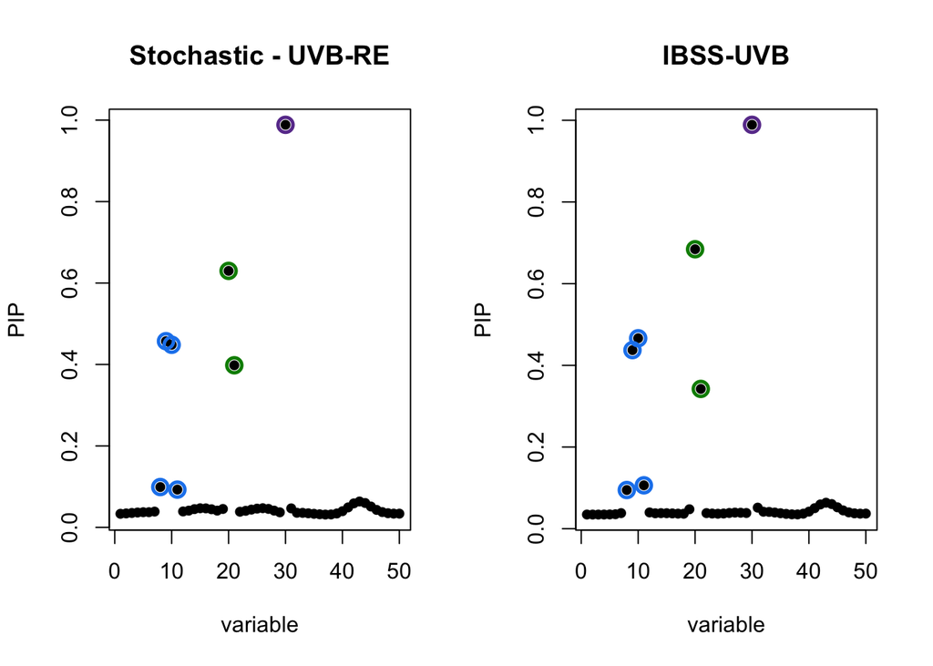

```r
par(mfrow = c(1, 2))
susie_plot2(stochastic_uvb_re_fit[[10]], data$X, main = 'Stochastic - UVB-RE')
susie_plot2(ibss_uvb_fit, data$X, main ='IBSS-UVB')
```